# Session 10 Supervised Machine Learning - Report Exerise

Tino Schneidewind

2025-05-24

## Comparison of linear regression and KNN models

The objective of this report exercise is to understand and explain the differences between linear regression and K-nearest neighbours models

### 1. Code from [Chapter 10](https://geco-bern.github.io/agds_book/supervised_ml_I.html) from the AGDS I book

```r
# load libraries
library(dplyr);library(tidyverse);library(caret);library(recipes)
library(yardstick);library(gridExtra);library(scales)
```

```r
# data
daily_fluxes <- read_csv("../data/daily_fluxes_re_ml_01.csv") |>
  select(TIMESTAMP,
         GPP_NT_VUT_REF,
         SW_IN_F,
         VPD_F,
         TA_F)

# for reproducability
set.seed(1982)

# data splitting
split <- rsample::initial_split(daily_fluxes, prop = 0.7, strata = "VPD_F")
daily_fluxes_train <- rsample::training(split)
daily_fluxes_test <- rsample::testing(split)

# model and pre-processing formulation, use all variables but LW_IN_F
pp <- recipes::recipe(GPP_NT_VUT_REF ~ SW_IN_F + VPD_F + TA_F,
                      data = daily_fluxes_train |> drop_na()) |>
  recipes::step_BoxCox(recipes::all_predictors()) |>
  recipes::step_center(recipes::all_numeric(), -recipes::all_outcomes()) |>
  recipes::step_scale(recipes::all_numeric(), -recipes::all_outcomes())


# linear model
mod_lm <- caret::train(
  pp,
  data = daily_fluxes_train |> drop_na(),
  method = "lm",
  trControl = caret::trainControl(method = "none"),
  metric = "RMSE"
)

# KNN model
mod_knn <- caret::train(
  pp,
  data = daily_fluxes_train |> drop_na(),
  method = "knn",
  trControl = caret::trainControl(method = "none"),
  tuneGrid = data.frame(k = 8),
  metric = "RMSE"
)

# load model eval, pred and MAE functions
source("../functions/eval_model.R")
```

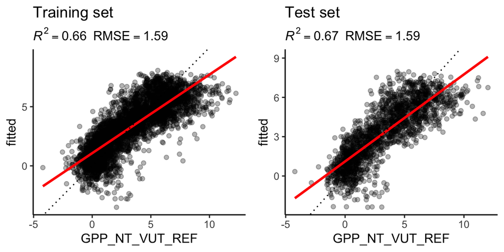

```r
# linear regression model
eval_model(mod = mod_lm, df_train = daily_fluxes_train, df_test = daily_fluxes_test)
```

*Figure 1: Model fit of GPP of the linear regression on the training and testing data set.*

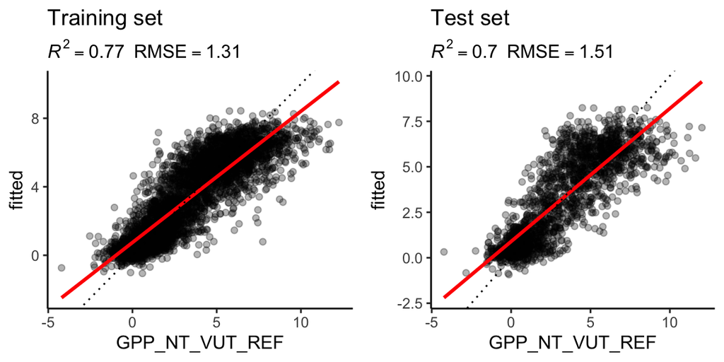

```r
# KNN
eval_model(mod = mod_knn, df_train = daily_fluxes_train, df_test = daily_fluxes_test)
```

*Figure 2: Model fit of GPP of the KNN model on the training and testing data set.*

### 2. Bias-variance trade-off differences

#### Q1: Why is the difference between the evaluation on the training and the test set larger for the KNN model than for the linear regression model?

The difference in evaluation between the training and test sets is larger for the KNN model than for the linear regression model due to differences in their bias-variance tradeoff.

KNN models have low bias (few assumptions about relationships in the data) but high variance, making them prone to overfitting. This means they capture noise in the training data, leading to strong performance on the training set but weaker generalization to new data, as seen in the lower test set accuracy. The fact that the KNN model performs slightly worse on the test set suggests it may be overfitting. A possible solution is to increase 𝐾 (currently set to 8) to smooth predictions and reduce variance.

In contrast, linear models have higher bias and lower variance, meaning they learn a simpler, more generalizable relationship between predictors and the outcome. This makes them more robust to unseen data, which could explain why the linear model performs better on the test set than on the training set.

#### Q2: Why does the evaluation on the test set indicate a better model performance of the KNN model than the linear regression model?

The KNN model demonstrates better performance on the test set than the linear regression model, as indicated by its higher $R^2$ and lower RMSE and is, in other words, better able to predict a larger portion of the variance of GPP in a dataset that was not used for training.

#### Q3: How would you position the KNN and the linear regression model along the spectrum of the bias-variance trade-off?

KNN and linear regression fall on opposite ends of the bias-variance trade-off. KNN has low bias (makes few assumptions about the data) but high variance, meaning it can capture complex patterns but is prone to overfitting. Linear regression has high bias (assumes a linear relationship) but low variance, making it more stable but less flexible for capturing complex relationships. KNN is better for capturing non-linear patterns, while linear regression generalizes well when the true relationship is approximately linear.

### 3. Temporal variations of modelled GPP

```r
# linear regression model
daily_fluxes$lm_fitted  <- pred_model(mod = mod_lm,
                                      df = daily_fluxes,
                                      df_train = daily_fluxes_train,
                                      df_test = daily_fluxes_test)

# KNN
daily_fluxes$knn_fitted <- pred_model(mod = mod_knn,
                                      df = daily_fluxes,
                                      df_train = daily_fluxes_train,
                                      df_test = daily_fluxes_test)
```

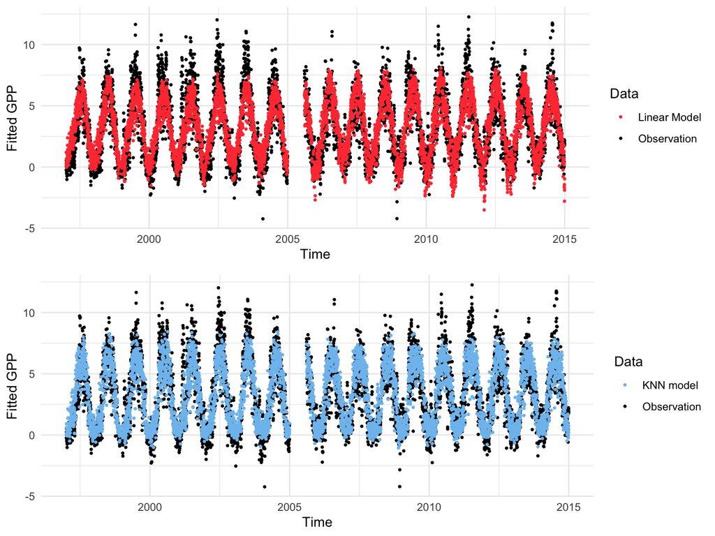

*Figure 3: Time series plots of comparing the linear model predictions (top) and the KNN model predictions (bottom) of GPP with observations.*

Figure 3 shows the temporal variation of observed GPP and the corresponding predictions from the linear regression and the KNN model. It is hard to compare model performance from this comparison but what is clearly visible is that both model struggle to capture the extremes of very low and very high GPP. This could be explained by the decreased availability of training data on these extremes.

## The role of k

### 1. Implications of k approaching 1 and the number of observations $N$

With k approaching 1, the model will more and more perfectly fit the data, which makes it very sensitive to noise. As a consequence, in the training data, the MAE would decrease and approach 0 while the $R^2$ would increase and approach 1. The opposite would be the case in the test data, where the MAE would increase due to overfitting and the $R^2$ would decrease.

With k approaching $N$, in the training data, the MAE would increase since we would be ignoring finer patterns, and the $R^2$ would approach 0 as the model essentially predicts the overall mean at $N$ k’s. In the test data, the $R^2$ would stay low due to underfitting and the MAE would increase as the model becomes too simplistic.

### 2. Visualization of the implications

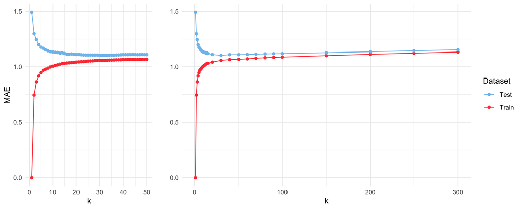

```r
# k's to compute MAE for with higher resolution of small k's
k_vec <- 1:50

# MAE plot function
plot_low = MAE_plot(vec = k_vec, df_train = daily_fluxes_train, df_test = daily_fluxes_test) +
  theme(legend.position = "none") +
  labs(x = "k")

# k's to compute MAE for with large k's
k_vec <- c(1:15,seq(20,100,10), seq(150,300,50))

# MAE plot function
plot_high = MAE_plot(vec = k_vec, df_train = daily_fluxes_train, df_test = daily_fluxes_test) +
  labs(y = "", x = "k")
```

*Figure 4: Relationship between k of the KNN model with the MAE in training and test data sets.*

Figure 4 shows the relationship between k and the MAE across a range of values. As hypothesized, when k approaches 1, the MAE decreases toward 0 in the training data, but increases in the test data, indicating overfitting and poor generalizability. As k approaches N, the MAE in the training data increases, but only slightly beyond a certain threshold. Similarly, the MAE in the test data increases beyond the same threshold as k increases, but only to a small degree with large k jumps.

The initial sharp decrease in test MAE as k increases from 1 reflects a region of overfitting, where small increases in k greatly improve generalizability. The region where increasing k no longer improves performance on the test set indicates underfitting, where the model becomes overly simplistic and fails to capture meaningful patterns in the data.

### 3. Determination of the optimal k

There are multiple methods for determining the optimal k. The most obvious would be to chose the one with the **lowest MAE score on the test set** as this indicates performance on unseen data.

```r
# k values
k_vec <- 1:50

# MAE table function
MAE_df = MAE_table(vec = k_vec, df_train = daily_fluxes_train, df_test = daily_fluxes_test)

# return k of minimum MAE on test set
MAE_df$k[which.min(MAE_df$MAE_test)]
```

```
## [1] 31
```

Another method of determining the optimal k is the **“elbow method”**, which indicates a distinct change in the slope of the k-MAE association. Visually this would be approximately located at k=10. Mathematically, this “elbow” can be defined using the **Kneedle algorithm**, which draws a line between the first and last points on the curve of k versus MAE and then determines the point on the curve, which has the largest perpendicular distance to the line.

```r
# normalize MAE and k
x_norm <- rescale(MAE_df$k); y_norm <- rescale(MAE_df$MAE_test)

# define endpoints
point1 <- c(x_norm[1], y_norm[1])
point2 <- c(x_norm[length(x_norm)], y_norm[length(y_norm)])

# compute distance to line
dist_to_line <- sapply(1:length(x_norm), function(i) {
  num <- abs((point2[2] - point1[2]) * x_norm[i] -
             (point2[1] - point1[1]) * y_norm[i] +
             point2[1] * point1[2] - point2[2] * point1[1])

  denom <- sqrt((point2[2] - point1[2])^2 + (point2[1] - point1[1])^2)

  num / denom
})

MAE_df$k[which.max(dist_to_line)]
```

```
## [1] 9
```

Another method to compute the optimal value for k is taking the **square root of the number of observations in the training data set and dividing them by two**, which is more a rule of thumb::

```r
sqrt(nrow(daily_fluxes_train)) / 2
```

```
## [1] 33.91165
```

This methods yields a value very close to the minimum test set MAE score and supports the initial most obvious method choice. In order to ensure that this minimum k of 31 does not depend on the randomly chosen single training and test data sets, **cross-validation** can be implemented. for this, we resample training and test sets multiple (in this case 5) times.

```r
# KNN model
mod_knn <- caret::train(
  pp,
  data = daily_fluxes_train |> drop_na(),
  method = "knn",
  trControl = caret::trainControl(method = "cv", number = 5),
  tuneGrid = data.frame(k = c(1:70, seq(80, 300, 20))),
  metric = "MAE"
)

# return the optimal k based on MAE
mod_knn$results$k[which.min(mod_knn$results$MAE)]
```

```
## [1] 45
```

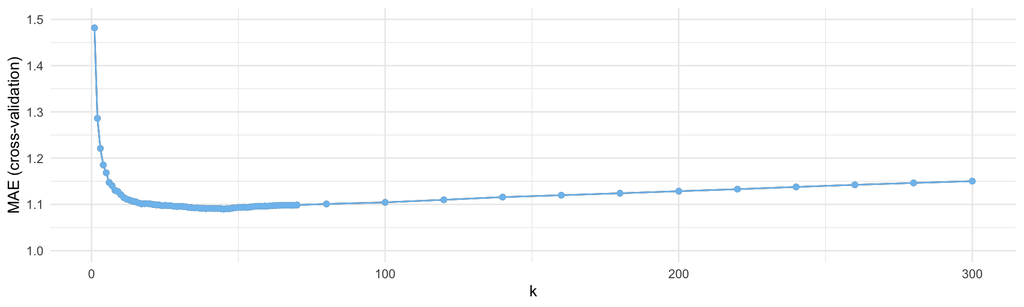

*Figure 5: Relationship between k of the KNN model with cross-validation and the MAE in the test data set.*

Cross-validation across multiple training and test sets return an optimal k, which is higher than what was returned from the initial training-test set (Figure 5). This indicates that there was a bias in our conclusion based on our choice of sample initially. In summary, a combination of the lowest MAE score with cross-validation yields the best estimate of the optimal value for k. Other methods like the elbow methods and Kneedle algorithm are available to provide efficient first guesses.